# R Notebook

```r
library(tidyverse)
library(stringr)
library(lubridate)
#library(naniar)
#library(validate)
library(janitor)
library(ggpubr)
```

```r
us_census <- read_csv("census_income_original_2.csv",
                          col_types = cols(
                            ID = col_character(),
                            age = col_double(),
                            workclass = col_character(),
                            education = col_character(),
                            education.num = col_double(),
                            marital.status = col_character(),
                            occupation = col_character(),
                            relationship = col_character(),
                            race  = col_character(),
                            Gender = col_character(),
                            capital.gain = col_double(),
                            capital.loss = col_double(),
                            hours.per.week = col_double(),
                            native.country = col_character(),
                            income = col_character(),
                            income_c  = col_double()

                          ))
```

```
57 parsing failures.
  row      col expected         actual                           file
23253 income_c a double Not applicable 'census_income_original_2.csv'
23894 income_c a double Not applicable 'census_income_original_2.csv'
29514 income_c a double Not applicable 'census_income_original_2.csv'
29523 income_c a double Not applicable 'census_income_original_2.csv'
29527 income_c a double Not applicable 'census_income_original_2.csv'
..... ........ ........ .............. ..............................
See problems(...) for more details.
```

```r
problems(us_census)
```

| row | col | expected | actual | file |
| --- | --- | --- | --- | --- |
| 23253 | income_c | a double | Not applicable | 'census_income_original_2.csv' |
| 23894 | income_c | a double | Not applicable | 'census_income_original_2.csv' |
| 29514 | income_c | a double | Not applicable | 'census_income_original_2.csv' |
| 29523 | income_c | a double | Not applicable | 'census_income_original_2.csv' |
| 29527 | income_c | a double | Not applicable | 'census_income_original_2.csv' |
| 29529 | income_c | a double | Not applicable | 'census_income_original_2.csv' |
| 30947 | income_c | a double | Not applicable | 'census_income_original_2.csv' |
| 30948 | income_c | a double | Not applicable | 'census_income_original_2.csv' |
| 30949 | income_c | a double | Not applicable | 'census_income_original_2.csv' |
| 30950 | income_c | a double | Not applicable | 'census_income_original_2.csv' |

[output cut: 47 more lines]

### now we replace the “Not applicable” in the income_c column with nulls.

```r
us_census <- read_csv("census_income_original_2.csv",
                          col_types = cols(
                            ID = col_character(),
                            age = col_double(),
                            workclass = col_character(),
                            education = col_character(),
                            education.num = col_double(),
                            marital.status = col_character(),
                            occupation = col_character(),
                            relationship = col_character(),
                            race  = col_character(),
                            Gender = col_character(),
                            capital.gain = col_double(),
                            capital.loss = col_double(),
                            hours.per.week = col_double(),
                            native.country = col_character(),
                            income = col_character(),
                            income_c  = col_character()

                          ))
```

### let’s check the Not Applicable columns.

```r
us_census_ch %>%
 filter(income_c == "Not applicable")
```

```
Error in filter(., income_c == "Not applicable") :
  object 'us_census_ch' not found
```

```r
##us_census_ch <- NA !!!!!
#us_census <-us_census %>% replace(income_c, "Not Applicable" , NA_character_)

us_census[us_census$income_c ==  "Not Applicable"] <- NA_character_
```

```
Error: Must assign to columns with a valid subscript vector.
i Logical subscripts must match the size of the indexed input.
x Input has size 16 but subscript `us_census$income_c == "Not Applicable"` has size 33333.
Run `rlang::last_error()` to see where the error occurred.
```

```r
us_census %>% nrow()
```

```
[1] 33333
```

```r
as.numeric("11")
```

```
[1] 11
```

###as.numeric(c(“1”, “Ham”))>>warning # Validation= ## Level 0 - Format & File structure ##Validate and fix reading file

##Very first step is to make sure you know your Unique Identifier

##As per the dataset information,ID is the unique identifier

##Once you know your identifier .. check for deuplicates ##checking for “duplicates” depending on file format wide Vs long

```r
us_census %>%
  distinct(ID) %>%
  nrow()
```

```
[1] 32561
```

#### this dataset is in wide format>> this helps in: does this increase voertime?

#### wide: all details for an observation are in 1 row.

#### 1 column over a period of time>> rows (why bring 120 column when u only need 1 ?)

#### time stamp>> long is better. static, doesn’t change over time (demographics, saken feen, )>> wide>> esmak marra w7da

#### duplicates definition differs from wide to long

#### long: composite pk. I must know the unique id: else, you could take 3 columns as unique while there are 5.

#### 1 1 1

#### 1 1 2

## Viewing duplicates

```r
us_census %>%
  group_by(ID) %>%
  filter(n() >1) %>%
  ungroup() %>%
  arrange(ID)
```

| ID | age | workclass | education | education.num | marital.status | occupation | relationship | race | Gender | capital.gain | capital.loss | hours.per.week | native.country | income | income_c |
| --- | --- | --- | --- | --- | --- | --- | --- | --- | --- | --- | --- | --- | --- | --- | --- |
| 10 | 41 | Private | Some-college | 10 | Never-married | Craft-repair | Unmarried | White | Male | 0 | 3004 | 60 | ? | >50K | NA |
| 10 | 41 | Private | Some-college | 10 | Never-married | Craft-repair | Unmarried | White | Male | 0 | 3004 | 60 | ? | >50K | NA |
| 100 | 59 | Private | Doctorate | 16 | Married-civ-spouse | Prof-specialty | Husband | White | M | 0 | 2415 | 45 | United-States | >50K | NA |
| 100 | 59 | Private | Doctorate | 16 | Married-civ-spouse | Prof-specialty | Husband | White | Male | 0 | 2415 | 45 | United-States | >50K | NA |
| 101 | 50 | Self-emp-inc | Prof-school | 15 | Married-civ-spouse | Prof-specialty | Husband | White | M | 0 | 2415 | 60 | United-States | >50K | NA |
| 101 | 50 | Self-emp-inc | Prof-school | 15 | Married-civ-spouse | Prof-specialty | Husband | White | Male | 0 | 2415 | 60 | United-States | >50K | NA |
| 102 | 46 | Private | Doctorate | 16 | Married-civ-spouse | Prof-specialty | Husband | White | M | 0 | 2415 | 55 | United-States | >50K | NA |
| 102 | 46 | Private | Doctorate | 16 | Married-civ-spouse | Prof-specialty | Husband | White | Male | 0 | 2415 | 55 | United-States | >50K | NA |
| 103 | 53 | Self-emp-not-inc | Bachelors | 13 | Married-civ-spouse | Exec-managerial | Husband | White | M | 0 | 2415 | 40 | United-States | >50K | NA |
| 103 | 53 | Self-emp-not-inc | Bachelors | 13 | Married-civ-spouse | Exec-managerial | Husband | White | Male | 0 | 2415 | 40 | United-States | >50K | NA |

[output cut: 990 more lines]

```r
NA
```

## remove duplicates

```r
us_census <- us_census %>%
  distinct(ID, .keep_all = TRUE)
us_census
```

| ID | age | workclass | education | education.num | marital.status | occupation | relationship | race | Gender | capital.gain | capital.loss | hours.per.week | native.country | income | income_c |
| --- | --- | --- | --- | --- | --- | --- | --- | --- | --- | --- | --- | --- | --- | --- | --- |
| 1 | 90 | ? | HS-grad | 9 | Widowed | ? | Not-in-family | White | Female | 0 | 4356 | 40 | United-States | <=50K | 7986 |
| 2 | 82 | Private | HS-grad | 9 | Widowed | Exec-managerial | Not-in-family | White | Female | 0 | 4356 | 18 | United-States | <=50K | 4566 |
| 3 | 66 | ? | Some-college | 10 | Widowed | ? | Unmarried | Black | Female | 0 | 4356 | 40 | United-States | <=50K | 2571 |
| 4 | 54 | Private | 7th-8th | 4 | Divorced | Machine-op-inspct | Unmarried | White | Female | 0 | 3900 | 40 | United-States | <=50K | 8611 |
| 5 | 41 | Private | Some-college | 10 | Separated | Prof-,specialty | Own-child | White | Female | 0 | 3900 | 40 | United-States | <=50K | 1553 |
| 6 | 34 | Private | HS-grad | 9 | Divorced | Other-service | Unmarried | White | female | 0 | 3770 | 45 | United-States | <=50K | 7560 |
| 7 | 38 | Private | 10th | 6 | Separated | Adm-clerical | Unmarried | White | Male | 0 | 3770 | 40 | United-States | <=50K | 4204 |
| 8 | 74 | State-gov | Doctorate | 16 | Never-married | Prof-,specialty | Other-relative | White | female | 0 | 3683 | 20 | United-States | >50K | NA |
| 9 | 68 | Federal-gov | HS-grad | 9 | Divorced | Prof-,specialty | Not-in-family | White | female | 0 | 3683 | 40 | United-States | <=50K | 481 |
| 10 | 41 | Private | Some-college | 10 | Never-married | Craft-repair | Unmarried | White | Male | 0 | 3004 | 60 | ? | >50K | NA |

[output cut: 990 more lines]

### 60% of the data is null. I WILL NOT FILL IT.

## Level 1 – Cells, records, file

##a)Aggregate Summary statsitcs

```r
us_census %>% select_if(is.numeric) %>%
  summary()
```

```
      age        education.num    capital.gain    capital.loss
 Min.   :17.00   Min.   : 1.00   Min.   :    0   Min.   :   0.0
 1st Qu.:28.00   1st Qu.: 9.00   1st Qu.:    0   1st Qu.:   0.0
 Median :37.00   Median :10.00   Median :    0   Median :   0.0
 Mean   :38.58   Mean   :10.08   Mean   : 1078   Mean   :  87.3
 3rd Qu.:48.00   3rd Qu.:12.00   3rd Qu.:    0   3rd Qu.:   0.0
 Max.   :90.00   Max.   :16.00   Max.   :99999   Max.   :4356.0
 hours.per.week
 Min.   : 1.00
 1st Qu.:40.00
 Median :40.00
 Mean   :40.44
 3rd Qu.:45.00
 Max.   :99.00
```

```r
us_census %>%
  filter(!is.na(income_c)) -> us_census_clean
us_census_clean
```

| ID | age | workclass | education | education.num | marital.status | occupation | relationship | race | Gender | capital.gain | capital.loss | hours.per.week | native.country | income | income_c |
| --- | --- | --- | --- | --- | --- | --- | --- | --- | --- | --- | --- | --- | --- | --- | --- |
| 1 | 90 | ? | HS-grad | 9 | Widowed | ? | Not-in-family | White | Female | 0 | 4356 | 40 | United-States | <=50K | 7986 |
| 2 | 82 | Private | HS-grad | 9 | Widowed | Exec-managerial | Not-in-family | White | Female | 0 | 4356 | 18 | United-States | <=50K | 4566 |
| 3 | 66 | ? | Some-college | 10 | Widowed | ? | Unmarried | Black | Female | 0 | 4356 | 40 | United-States | <=50K | 2571 |
| 4 | 54 | Private | 7th-8th | 4 | Divorced | Machine-op-inspct | Unmarried | White | Female | 0 | 3900 | 40 | United-States | <=50K | 8611 |
| 5 | 41 | Private | Some-college | 10 | Separated | Prof-,specialty | Own-child | White | Female | 0 | 3900 | 40 | United-States | <=50K | 1553 |
| 6 | 34 | Private | HS-grad | 9 | Divorced | Other-service | Unmarried | White | female | 0 | 3770 | 45 | United-States | <=50K | 7560 |
| 7 | 38 | Private | 10th | 6 | Separated | Adm-clerical | Unmarried | White | Male | 0 | 3770 | 40 | United-States | <=50K | 4204 |
| 9 | 68 | Federal-gov | HS-grad | 9 | Divorced | Prof-,specialty | Not-in-family | White | female | 0 | 3683 | 40 | United-States | <=50K | 481 |
| 22 | 29 | Private | 11th | 7 | Separated | Sales | Not-in-family | White | female | 0 | 2754 | 42 | United-States | <=50K | 1992 |
| 23 | 61 | Private | HS-grad | 9 | Divorced | Sales | Unmarried | White | female | 0 | 2754 | 25 | United-States | <=50K | 8224 |

[output cut: 990 more lines]

## Level 1 – Cells, records, file

##b)Dataset consistency checks “columns cross validation”

#### income vs income_c

```r
us_census_clean %>%
  mutate(income_validate = case_when(income == "<=50K" ~ 1, TRUE ~ 0)) %>%
  filter(income_validate == 1 && income>50000)
```

| ID | age | workclass | education | education.num | marital.status | occupation | relationship | race | Gender | capital.gain | capital.loss | hours.per.week | native.country | income | income_c | income_validate |
| --- | --- | --- | --- | --- | --- | --- | --- | --- | --- | --- | --- | --- | --- | --- | --- | --- |

```r
NA
```

```r
us_census_clean %>%
  mutate(income_validate = case_when(income == ">50K" ~ 1, TRUE ~ 0)) %>%
  filter(income_validate == 1 && income<=50000)
```

| ID | age | workclass | education | education.num | marital.status | occupation | relationship | race | Gender | capital.gain | capital.loss | hours.per.week | native.country | income | income_c | income_validate |
| --- | --- | --- | --- | --- | --- | --- | --- | --- | --- | --- | --- | --- | --- | --- | --- | --- |

```r
NA
```

#### no need to do further adjustments to this pair of columns.

# Q1. Is there a relationship between age and income?

```r
select(us_census_clean, income, age) %>%
  select_if(is.numeric) %>%
  summary()
```

```
      age
 Min.   :17.00
 1st Qu.:25.00
 Median :34.00
 Mean   :37.05
 3rd Qu.:46.00
 Max.   :90.00
```

```r
#select(us_census_clean, income, age)
us_census_clean %>%
  filter(income == ">50K") %>%
  select_if(is.numeric) %>%
  summary()
```

```
      age        education.num   capital.gain    capital.loss
 Min.   :22.00   Min.   : 4.0   Min.   :    0   Min.   :0
 1st Qu.:35.00   1st Qu.:10.0   1st Qu.:    0   1st Qu.:0
 Median :44.00   Median :13.0   Median :    0   Median :0
 Mean   :44.08   Mean   :11.8   Mean   :26822   Mean   :0
 3rd Qu.:52.00   3rd Qu.:13.0   3rd Qu.:99999   3rd Qu.:0
 Max.   :65.00   Max.   :16.0   Max.   :99999   Max.   :0
 hours.per.week
 Min.   :16.00
 1st Qu.:40.00
 Median :40.00
 Mean   :44.62
 3rd Qu.:50.00
 Max.   :70.00
```

### The summary statistic shows us that the median age for the higher income group is greater than the median age of the lower income group. This indicates that older people tend to have salaries >50K. But let’s validate this assumption using a box plot.

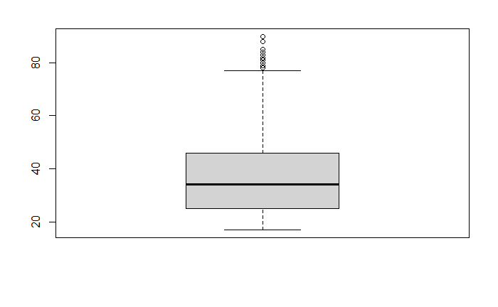

```r
us_census_clean %>%
  filter(income == "<=50K") -> us_census_LT_50k
boxplot(us_census_LT_50k$age)
```

### The data is right skewed. most of the people who earn <=50K are aged between 25 and 46

```r
us_census_clean %>%
  filter(income == ">50K") -> us_census_GT_50k
boxplot(us_census_GT_50k$age)
```

[output not shown]

### The data is nearly normal. most of the people who earn >50K are aged between 35 and 52

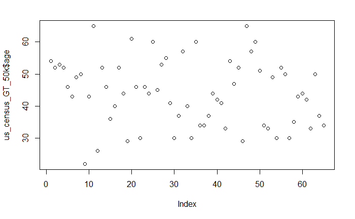

```r
plot(us_census_GT_50k$age)
```

```r
plot(us_census_LT_50k$age)
```

[output not shown]

### Answer: There isn’t a clear relationship between age and income. However, the scatter plot shows us that the data has more observations of the “<=50K” category than the “>50K”.

# Q2. Can we say that we have achieved gender equality?

#### to answer this question, let’s first investigate the Gender column.

```r
us_census_clean
```

| ID | age | workclass | education | education.num | marital.status | occupation | relationship | race | Gender | capital.gain | capital.loss | hours.per.week | native.country | income | income_c |
| --- | --- | --- | --- | --- | --- | --- | --- | --- | --- | --- | --- | --- | --- | --- | --- |
| 1 | 90 | ? | HS-grad | 9 | Widowed | ? | Not-in-family | White | Female | 0 | 4356 | 40 | United-States | <=50K | 7986 |
| 2 | 82 | Private | HS-grad | 9 | Widowed | Exec-managerial | Not-in-family | White | Female | 0 | 4356 | 18 | United-States | <=50K | 4566 |
| 3 | 66 | ? | Some-college | 10 | Widowed | ? | Unmarried | Black | Female | 0 | 4356 | 40 | United-States | <=50K | 2571 |
| 4 | 54 | Private | 7th-8th | 4 | Divorced | Machine-op-inspct | Unmarried | White | Female | 0 | 3900 | 40 | United-States | <=50K | 8611 |
| 5 | 41 | Private | Some-college | 10 | Separated | Prof-,specialty | Own-child | White | Female | 0 | 3900 | 40 | United-States | <=50K | 1553 |
| 6 | 34 | Private | HS-grad | 9 | Divorced | Other-service | Unmarried | White | female | 0 | 3770 | 45 | United-States | <=50K | 7560 |
| 7 | 38 | Private | 10th | 6 | Separated | Adm-clerical | Unmarried | White | Male | 0 | 3770 | 40 | United-States | <=50K | 4204 |
| 9 | 68 | Federal-gov | HS-grad | 9 | Divorced | Prof-,specialty | Not-in-family | White | female | 0 | 3683 | 40 | United-States | <=50K | 481 |
| 22 | 29 | Private | 11th | 7 | Separated | Sales | Not-in-family | White | female | 0 | 2754 | 42 | United-States | <=50K | 1992 |
| 23 | 61 | Private | HS-grad | 9 | Divorced | Sales | Unmarried | White | female | 0 | 2754 | 25 | United-States | <=50K | 8224 |

[output cut: 990 more lines]

### It’s clear that this column’s values needs to be unified into; M and F

```r
unique(us_census_clean$Gender)
```

```
[1] "Female" "female" "Male"   "M"      "malee"  "male"   "f"
[8] "m"
```

```r
us_census_clean %>%
  mutate(Gender_clean = case_when(tolower(Gender) == "female" ~ "F", tolower(Gender)== "male" ~ "M", Gender == "malee" ~ "M", tolower(Gender) == "m" ~ "M", tolower(Gender) == "f" ~ "F", TRUE ~ "Non")) -> us_census_clean
```

### checking

```r
 # unique(us_census_clean$Gender_clean)
us_census_clean %>%
  filter(Gender_clean == "Non")
```

| ID | age | workclass | education | education.num | marital.status | occupation | relationship | race | Gender | capital.gain | capital.loss | hours.per.week | native.country | income | income_c | Gender_clean |
| --- | --- | --- | --- | --- | --- | --- | --- | --- | --- | --- | --- | --- | --- | --- | --- | --- |

### Now, let’s start answering the second question.

```r
tabyl(us_census_clean$Gender_clean)
```

```
 us_census_clean$Gender_clean    n   percent
                            F 4977 0.3841463
                            M 7979 0.6158537
```

### In general, there’s 38.41% females and 61.58% males in the sample data. (this doesn’t give us an indication about inequality). An interesting variable that might determine equality is the workforce; how does the percentage of people working in the private sector differs from males to females?

```r
us_census_clean %>%
  filter(Gender_clean =="M",  workclass == "Private")
```

| ID | age | workclass | education | education.num | marital.status | occupation | relationship | race | Gender | capital.gain | capital.loss | hours.per.week | native.country | income | income_c | Gender_clean |
| --- | --- | --- | --- | --- | --- | --- | --- | --- | --- | --- | --- | --- | --- | --- | --- | --- |
| 7 | 38 | Private | 10th | 6 | Separated | Adm-clerical | Unmarried | White | Male | 0 | 3770 | 40 | United-States | <=50K | 4204 | M |
| 24 | 51 | Private | Some-college | 10 | Married-civ-spouse | Transport-moving | Husband | White | M | 0 | 2603 | 40 | United-States | <=50K | 8725 | M |
| 26 | 21 | Private | Assoc-voc | 11 | Married-civ-spouse | Craft-repair | Husband | White | M | 0 | 2603 | 40 | United-States | <=50K | 8338 | M |
| 27 | 33 | Private | 1st-4th | 2 | Married-civ-spouse | Craft-repair | Not-in-family | White | M | 0 | 2603 | 32 | Mexico | <=50K | 8257 | M |
| 28 | 49 | Private | 5th-6th | 3 | Married-civ-spouse | Other-service | Husband | White | M | 0 | 2603 | 40 | Greece | <=50K | 6809 | M |
| 47 | 71 | Private | HS-grad | 9 | Married-civ-spouse | Sales | Husband | White | M | 0 | 2467 | 52 | United-States | <=50K | 1802 | M |
| 121 | 26 | Private | Assoc-voc | 11 | Married-civ-spouse | Adm-clerical | Husband | White | M | 0 | 2377 | 45 | United-States | <=50K | 6411 | M |
| 124 | 36 | Private | HS-grad | 9 | Married-civ-spouse | Prof-specialty | Husband | White | M | 0 | 2377 | 60 | United-States | <=50K | 2647 | M |
| 128 | 23 | Private | HS-grad | 9 | Married-civ-spouse | Sales | Husband | White | M | 0 | 2377 | 40 | United-States | <=50K | 2406 | M |
| 135 | 52 | Private | HS-grad | 9 | Married-civ-spouse | Sales | Husband | Black | Male | 0 | 2377 | 40 | United-States | <=50K | 5600 | M |

[output cut: 990 more lines]

### There are 5,602 males working in the private sector.

```r
us_census_clean %>%
  filter(Gender_clean =="F",  workclass == "Private")
```

| ID | age | workclass | education | education.num | marital.status | occupation | relationship | race | Gender | capital.gain | capital.loss | hours.per.week | native.country | income | income_c | Gender_clean |
| --- | --- | --- | --- | --- | --- | --- | --- | --- | --- | --- | --- | --- | --- | --- | --- | --- |
| 2 | 82 | Private | HS-grad | 9 | Widowed | Exec-managerial | Not-in-family | White | Female | 0 | 4356 | 18 | United-States | <=50K | 4566 | F |
| 4 | 54 | Private | 7th-8th | 4 | Divorced | Machine-op-inspct | Unmarried | White | Female | 0 | 3900 | 40 | United-States | <=50K | 8611 | F |
| 5 | 41 | Private | Some-college | 10 | Separated | Prof-,specialty | Own-child | White | Female | 0 | 3900 | 40 | United-States | <=50K | 1553 | F |
| 6 | 34 | Private | HS-grad | 9 | Divorced | Other-service | Unmarried | White | female | 0 | 3770 | 45 | United-States | <=50K | 7560 | F |
| 22 | 29 | Private | 11th | 7 | Separated | Sales | Not-in-family | White | female | 0 | 2754 | 42 | United-States | <=50K | 1992 | F |
| 23 | 61 | Private | HS-grad | 9 | Divorced | Sales | Unmarried | White | female | 0 | 2754 | 25 | United-States | <=50K | 8224 | F |
| 126 | 27 | Private | Some-college | 10 | Married-civ-spouse | Adm-clerical | Wife | Black | female | 0 | 2377 | 20 | United-States | <=50K | 150 | F |
| 143 | 46 | Private | 5th-6th | 3 | Divorced | Craft-repair | Not-in-family | White | female | 0 | 2339 | 45 | United-States | <=50K | 6631 | F |
| 150 | 25 | Private | Bachelors | 13 | Never-married | Prof-,specialty | Own-child | White | female | 0 | 2339 | 35 | United-States | <=50K | 2194 | F |
| 151 | 55 | Private | Some-college | 10 | Never-married | Adm-clerical | Not-in-family | Black | female | 0 | 2339 | 45 | ? | <=50K | 4276 | F |

[output cut: 990 more lines]

### There are 3,631 females working in the private sector.

### So, assuming that the sample is representative, we didn’t reach gender equality yet.

#### The correct approach is to use a chi-square test to ensure if the difference between the 2 counts is statistically significant.

### now let’s investigate teh gender vs the income

```r
tabyl(us_census_GT_50k$Gender )
```

```
 us_census_GT_50k$Gender  n   percent
                  Female  9 0.1384615
                    Male 56 0.8615385
```

```r
tabyl(us_census_LT_50k$Gender)
```

```
 us_census_LT_50k$Gender    n      percent
                       f   67 0.0051974246
                  female   61 0.0047319836
                  Female 4840 0.3754557443
                       m    2 0.0001551470
                       M  133 0.0103172756
                    male    1 0.0000775735
                    Male 7786 0.6039872779
                   malee    1 0.0000775735
```

### 38% of females, and around 60% of males. This makes us pause and wonder; does the data rpovide convincing evidence about inequality?

# Q3. What other attribute/s could be an income predictor/s?

### Here, we should use linear regression to test this. the dependant variable is the income_c (since the output variable must be continous, I’ll use income_c this time). To decide which variables are good candidates for predictors, we plot education level against income_c.

```r
unique(us_census_clean$workclass)
```

[output not shown]

```r
us_census_clean %>%
  filter(!is.na(income_c)) -> us_census_inc
```

### let’s see if education ccould be a predictor for income_c?

```r
plot(us_census_inc$education.num, us_census_inc$income_c, xlim = c(0, 15), ylim = c(0, 2000))
```

[output not shown]

### clearly, there isn’t a clear linear relationship between the income_c and the education level.

```r
tabyl(us_census_GT_50k$workclass)
```

```
 us_census_GT_50k$workclass  n    percent
                          ?  2 0.03076923
                Federal-gov  3 0.04615385
                  Local-gov  2 0.03076923
                    Private 41 0.63076923
               Self-emp-inc  8 0.12307692
           Self-emp-not-inc  8 0.12307692
                  State-gov  1 0.01538462
```

```r
tabyl(us_census_LT_50k$workclass)
```

```
 us_census_LT_50k$workclass    n     percent
                          ?  870 0.067488946
                Federal-gov  322 0.024978667
                  Local-gov  788 0.061127919
               Never-worked    4 0.000310294
                    Private 9192 0.713055620
               Self-emp-inc  264 0.020479404
           Self-emp-not-inc  968 0.075091149
                  State-gov  479 0.037157707
                Without-pay    4 0.000310294
```

```r
tabyl(us_census_GT_50k$education)
```

```
 us_census_GT_50k$education  n    percent
                       12th  1 0.01538462
                    7th-8th  1 0.01538462
                 Assoc-acdm  1 0.01538462
                  Assoc-voc  3 0.04615385
                  Bachelors 21 0.32307692
                  Doctorate  3 0.04615385
                    HS-grad 13 0.20000000
                    Masters  3 0.04615385
                Prof-school  8 0.12307692
               Some-college 11 0.16923077
```